# NOAA Storm Database and severe weather events.

Jun Li jun.li3@bms.com

# Introduction

Introduction Storms and other severe weather events can cause both public health and economic problems for communities and municipalities. Many severe events can result in fatalities, injuries, and property damage, and preventing such outcomes to the extent possible is a key concern. This project involves exploring the U.S. National Oceanic and Atmospheric Administration’s (NOAA) storm database. This database tracks characteristics of major storms and weather events in the United States, including when and where they occur, as well as estimates of any fatalities, injuries, and property damage.

# Data

# Assignment

The basic goal of this assignment is to explore the NOAA Storm Database and answer some basic questions about severe weather events. You must use the database to answer the questions below and show the code for your entire analysis. Your analysis can consist of tables, figures, or other summaries. You may use any R package you want to support your analysis.

Two Questions to address

1. Across the United States, which types of events (as indicated in the EVTYPE variable) are most harmful with respect to population health?
2. Across the United States, which types of events have the greatest economic consequences?

# Load Libraries

```r
library(dplyr)
library(ggplot2)
library(reshape2)
library(printr) # Pretty printing in knitr
library(gplots)
library(plyr)
library(gridExtra)
```

# Read Data

```r
storm = read.csv("repdata-data-StormData.csv", header = TRUE, sep = ",")
storm <- mutate_each(storm, funs(toupper))
```

# Events most harmful to population health: fatalities and Injuries

```r
event = as.data.frame(storm[, c("EVTYPE" , "FATALITIES", "INJURIES")])
event[,2]<- as.numeric(event[,2])
event[,3]<- as.numeric(event[,3])
colclass <- lapply(event, class)
colclass
```

```
## $EVTYPE
## [1] "character"
##
## $FATALITIES
## [1] "numeric"
##
## $INJURIES
## [1] "numeric"
```

## Events Causing Fatalities

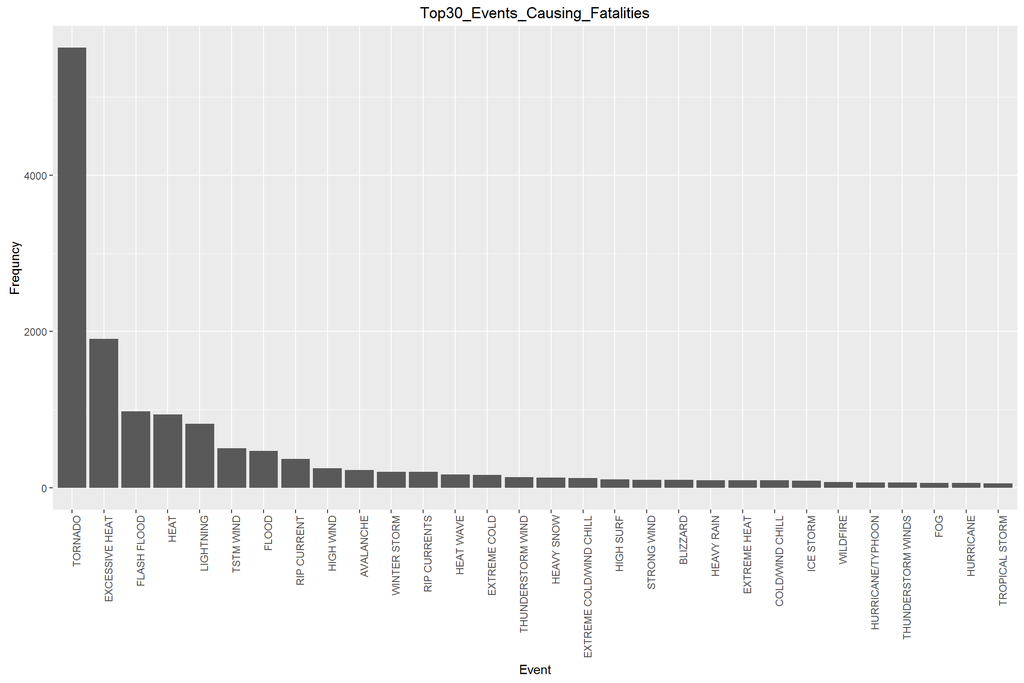

```r
event_agg <- aggregate(x=event[,2], by=list(event[,1]), FUN=sum, na.rm=TRUE)
names(event_agg)[1] <- colnames(event[1])
names(event_agg)[2] <- colnames(event[2])

event_order<- event_agg[order(event_agg[,2], decreasing = TRUE),]
Top30 <- event_order[1:30,]
rownames(Top30) <- NULL
eve_counts <- Top30[,2]
eve_list <- c(Top30[,1])
eve_name <- Top30[,1]

g <- ggplot(Top30, aes(x = reorder(eve_list, -eve_counts), y = eve_counts)) +
        geom_bar(stat = "identity") +
        ggtitle("Top30_Events_Causing_Fatalities") +
        labs(x="Event",y="Frequncy") +
        theme(axis.text.x = element_text(angle = 90, hjust = 1))
print(g)
```

```r
png(file = "Top_30_Events_Causing_Fatalities.png", width=8,height=6, units = 'in', res = 300)

tb <- knitr::kable(Top30, digits = 5, caption = "Top_30_Events_Causing_Fatalities", col.names = c("Events" , "Fatalities"))
print(tb)
```

```
##
##
## Table: Top_30_Events_Causing_Fatalities
##
## Events                     Fatalities
## ------------------------  -----------
## TORNADO                          5633
## EXCESSIVE HEAT                   1903
## FLASH FLOOD                       978
## HEAT                              937
## LIGHTNING                         816
## TSTM WIND                         504
## FLOOD                             470
## RIP CURRENT                       368
## HIGH WIND                         248
## AVALANCHE                         224
## WINTER STORM                      206
## RIP CURRENTS                      204
## HEAT WAVE                         172
## EXTREME COLD                      162
## THUNDERSTORM WIND                 133
## HEAVY SNOW                        127
## EXTREME COLD/WIND CHILL           125
## HIGH SURF                         104
## STRONG WIND                       103
## BLIZZARD                          101
## HEAVY RAIN                         98
## EXTREME HEAT                       96
## COLD/WIND CHILL                    95
## ICE STORM                          89
## WILDFIRE                           75
## HURRICANE/TYPHOON                  64
## THUNDERSTORM WINDS                 64
## FOG                                62
## HURRICANE                          61
## TROPICAL STORM                     58
```

## Events Causing Injuries

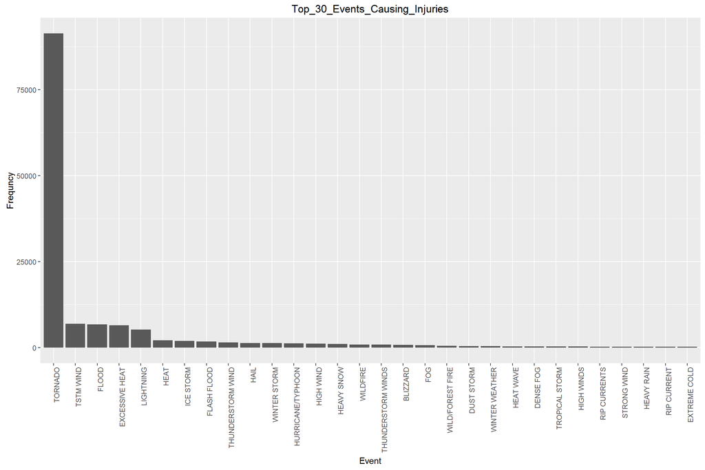

```r
event_agg2 <- aggregate(x=event[,3], by=list(event[,1]), FUN=sum, na.rm=TRUE)
names(event_agg2)[1] <- colnames(event[1])
names(event_agg2)[2] <- colnames(event[3])

event_order2<- event_agg2[order(event_agg2[,2], decreasing = TRUE),]
Top30_2 <- event_order2[1:30,]
rownames(Top30_2) <- NULL
eve_counts2 <- Top30_2[,2]
eve_list2 <- c(Top30_2[,1])
eve_name2 <- Top30_2[,1]

g2 <- ggplot(Top30_2, aes(x = reorder(eve_list2, -eve_counts2), y = eve_counts2)) +
        geom_bar(stat = "identity") +
        ggtitle("Top_30_Events_Causing_Injuries") +
        labs(x="Event",y="Frequncy") +
        theme(axis.text.x = element_text(angle = 90, hjust = 1))
print(g2)
```

```r
png(file = "Top_30_Events_Causing_Injuries.png", width=8,height=6, units = 'in', res = 300)

tb2 <- knitr::kable(Top30_2, digits = 5, caption = "Top_30_Events_Causing_Injuries", col.names = c("Events" , "Injuries"))
print(tb2)
```

```
##
##
## Table: Top_30_Events_Causing_Injuries
##
## Events                Injuries
## -------------------  ---------
## TORNADO                  91346
## TSTM WIND                 6957
## FLOOD                     6789
## EXCESSIVE HEAT            6525
## LIGHTNING                 5230
## HEAT                      2100
## ICE STORM                 1975
## FLASH FLOOD               1777
## THUNDERSTORM WIND         1488
## HAIL                      1361
## WINTER STORM              1321
## HURRICANE/TYPHOON         1275
## HIGH WIND                 1137
## HEAVY SNOW                1021
## WILDFIRE                   911
## THUNDERSTORM WINDS         908
## BLIZZARD                   805
## FOG                        734
## WILD/FOREST FIRE           545
## DUST STORM                 440
## WINTER WEATHER             398
## HEAT WAVE                  379
## DENSE FOG                  342
## TROPICAL STORM             340
## HIGH WINDS                 302
## RIP CURRENTS               297
## STRONG WIND                280
## HEAVY RAIN                 251
## RIP CURRENT                232
## EXTREME COLD               231
```

# Events have the greatest economic consequences

```
##  [1] ""  "-" "?" "+" "0" "1" "2" "3" "4" "5" "6" "7" "8" "B" "H" "K" "M"
```

```
## $EVTYPE
## [1] "character"
##
## $PROPDMG
## [1] "numeric"
##
## $PROPDMGEXP
## [1] "character"
```

## Events causing Property Damage

```
## $EVTYPE
## [1] "character"
##
## $PROPDMG
## [1] "numeric"
##
## $PROPDMGEXP
## [1] "character"
```

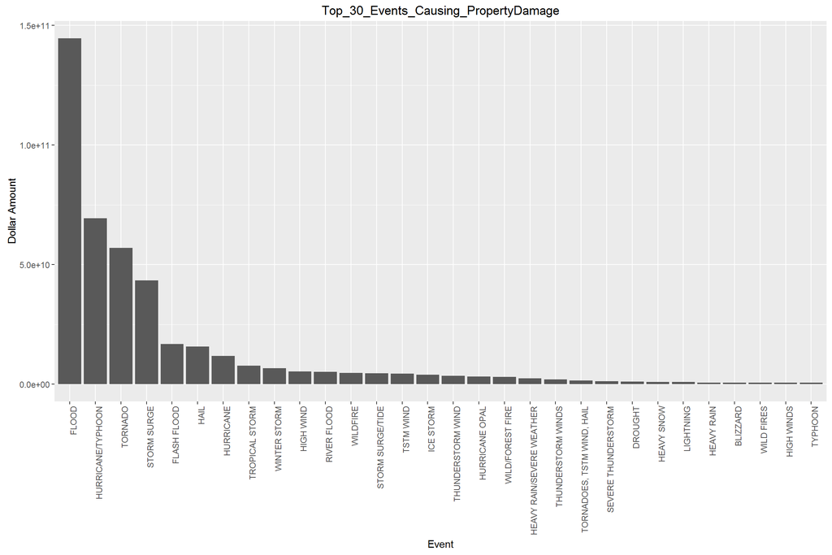

```r
propnew_agg <- aggregate(x=propnew[,2], by=list(propnew[,1]), FUN=sum, na.rm=TRUE)
names(propnew_agg)[1] <- colnames(propnew[1])
names(propnew_agg)[2] <- colnames(propnew[2])

propnew_order<- propnew_agg[order(propnew_agg[,2], decreasing = TRUE),]
Top30_ProDmg <- propnew_order[1:30,]
eve_counts <- Top30_ProDmg[,2]
eve_list <- c(Top30_ProDmg[,1])
eve_name <- Top30_ProDmg[,1]

g <- ggplot(Top30_ProDmg, aes(x = reorder(eve_list, -eve_counts), y = eve_counts)) +
        geom_bar(stat = "identity") +
        ggtitle("Top_30_Events_Causing_PropertyDamage") +
        labs(x="Event",y="Dollar Amount") +
        theme(axis.text.x = element_text(angle = 90, hjust = 1))
print(g)
```

```r
png(file = "Top_30_Events_Causing_PropertyDamage.png", width=8,height=6, units = 'in', res = 300)

tb3 <- knitr::kable(Top30_ProDmg, digits = 5, caption = "Top_30_Events_Causing_PropertyDamage", col.names = c("Events" , "PropDmg"))
print(tb3)
```

```
##
##
## Table: Top_30_Events_Causing_PropertyDamage
##
##       Events                             PropDmg
## ----  ---------------------------  -------------
## 154   FLOOD                         144657709807
## 372   HURRICANE/TYPHOON              69305840000
## 758   TORNADO                        56947380677
## 599   STORM SURGE                    43323536000
## 138   FLASH FLOOD                    16822673979
## 212   HAIL                           15735267513
## 363   HURRICANE                      11868319010
## 772   TROPICAL STORM                  7703890550
## 888   WINTER STORM                    6688497251
```

[output cut: 21 more lines]

## Events Causing CROP DAMAGE

```
## [1] ""  "?" "0" "2" "B" "K" "M"
```

```
## $EVTYPE
## [1] "character"
##
## $CROPDMG
## [1] "numeric"
##
## $CROPDMGEXP
## [1] "character"
```

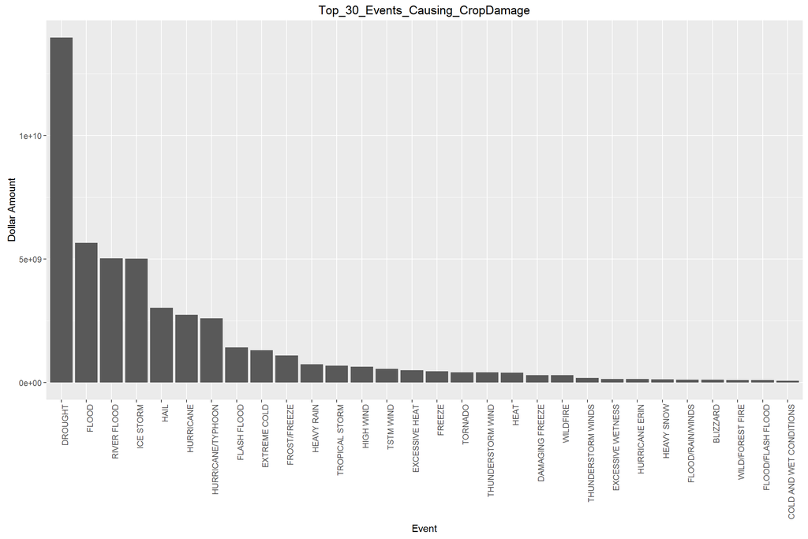

```r
cropnew_order<- cropnew_agg[order(cropnew_agg[,2], decreasing = TRUE),]
Top30_CropDmg <- cropnew_order[1:30,]
eve_counts <- Top30_CropDmg[,2]
eve_list <- c(Top30_CropDmg[,1])
eve_name <- Top30_CropDmg[,1]

g <- ggplot(Top30_CropDmg, aes(x = reorder(eve_list, -eve_counts), y = eve_counts)) +
        geom_bar(stat = "identity") +
        ggtitle("Top_30_Events_Causing_CropDamage") +
        labs(x="Event",y="Dollar Amount") +
        theme(axis.text.x = element_text(angle = 90, hjust = 1))
print(g)
```

```r
png(file = "Top_30_Events_Causing_CropDamage.png", width=8,height=6, units = 'in', res = 300)

tb4 <- knitr::kable(Top30_CropDmg, digits = 5, caption = "Top_30_Events_Causing_CropDamage", col.names = c("Events" , "CropDmg"))
print(tb4)
```

```
##
##
## Table: Top_30_Events_Causing_CropDamage
##
##       Events                         CropDmg
## ----  ------------------------  ------------
## 84    DROUGHT                    13972566000
## 154   FLOOD                       5661968450
## 529   RIVER FLOOD                 5029459000
## 387   ICE STORM                   5022113500
## 212   HAIL                        3025954473
## 363   HURRICANE                   2741910000
## 372   HURRICANE/TYPHOON           2607872800
## 138   FLASH FLOOD                 1421317100
## 125   EXTREME COLD                1312973000
```

[output cut: 21 more lines]

## System Information

*Time required to process this report:* *2.674353 mins*